# 당신이 계속 중위 연령이었던 이유

# 3 2016년, 법은 정년을 올렸고 현실은 움직이지 않았다

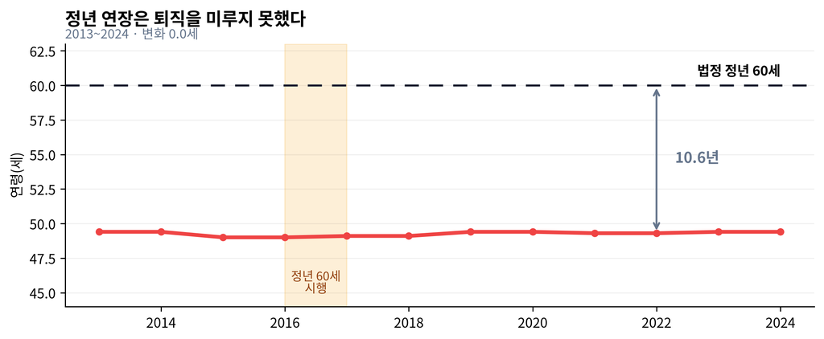

2013년 49.4세, 2024년 **49.4세**. 12년 동안 소수점 첫째 자리까지 같다. 그 사이 법정 정년은 55세 안팎 관행에서 **60세**로 올랐다.

법과 현실 사이에 **10.6년**의 빈 구간이 있다. 정년 연장이 만든 것은 “모두가 60세까지 다니는 사회”가 아니라 **60세까지 다닐 수 있는 사람과 없는 사람의 격차**였다.

# 4 1976년생 코호트: 중위에 머문다는 착각

이제 한 코호트를 따라가 보자. **1976년생**, 2001년 반도체·디스플레이 업계 입사. 이 코호트는 “시간이 지나도 계속 중위 연령이었다”고 체감한다. 검증 가능한 주장이다.

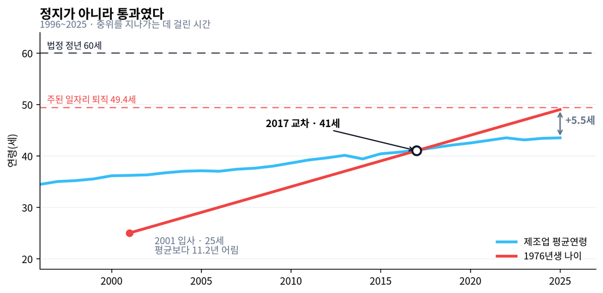

그림 4: 1976년생의 나이(빨강)와 제조업 평균연령(파랑). 입사 시점엔 11.2년 어렸고 2017년에 교차한 뒤 지금은 5.5년 많다. 붉은 점선은 주된 일자리 퇴직 평균연령 49.4세. 출처: 동 조사 + 고령층 부가조사.

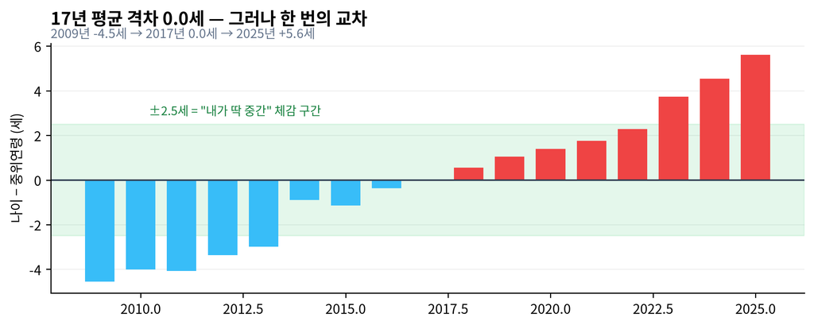

그림 5: 1976년생과 제조업 중위연령의 격차. 2009~2025년 평균은 정확히 0.0세이지만, 이는 머문 것이 아니라 가로지른 것이다. 음영은 ±2.5세 구간.

2009~2025년 17년간 이 코호트와 제조업 중위 연령의 **격차 평균은 정확히 0.0세**다. 체감은 통계적으로 정확하다.

그러나 그것은 **머무름이 아니라 통과**였다. 2001년 입사 때 11.2년 어렸고, 2017년에 교차했고, 2025년에 5.5년 많다. 24년에 걸쳐 격차가 16.7년 움직였다.

왜 정지처럼 느껴졌나. **중위는 연 0.36세, 사람은 연 1.00세**로 늙는다. 차이가 0.64세/년뿐이라 ±2.5세 구간을 벗어나는 데 **9년**이 걸렸다. 인생의 9년은 길다. 길어서 **정지로 오인된다**.

**중요중위 연령의 함정**

중위 연령에 오래 머물렀다는 체감은 **자신이 전형적이라는 증거가 아니다.** 그것은 조직의 중위가 **자기 속도의 3분의 1로만 따라오고 있다**는 뜻이다. 사람이 중위를 향해 간 것이 아니라, 중위가 사람을 향해 끌려온 것이다. 끌려온 이유는 하나다 — **아래가 채워지지 않았다.**

# 5 중위가 끌려온 이유

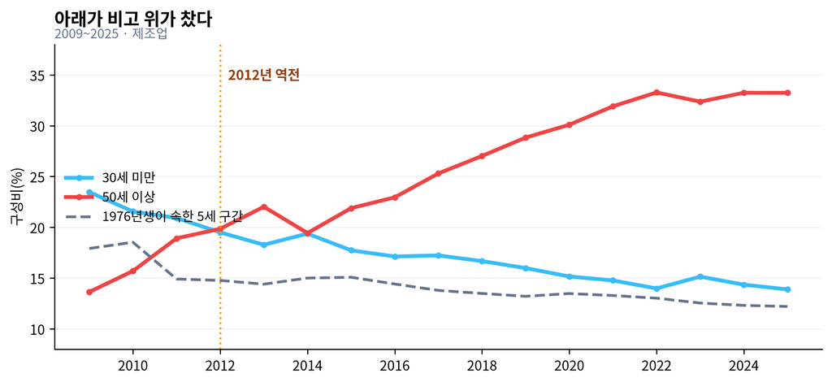

그림 6: 제조업 연령 구성비. 30세 미만이 반토막 나는 동안 50세 이상은 2.4배가 됐고, 둘은 2012년에 역전했다. 출처: 동 조사 연령계층별 근로자수에서 직접 산출.

30세 미만 비중은 **23.5% → 13.9%**로 반토막 났고, 50세 이상은 **13.6% → 33.2%**로 2.4배가 됐다. 둘이 뒤집힌 해는 **2012년**이다.

여기에 세 번째 선이 있다. **1976년생이 속한 5세 구간의 비중도 17.9% → 12.2%로 떨어졌다.** 같이 들어온 사람들이 나갔다는 뜻이다.

그러므로 “우리 세대가 계속 중심이었다”는 감각에는 **생존자 편향**이 섞여 있다. 나간 동기는 분포에서 사라지므로 체감에 잡히지 않는다. 남은 사람에게는 자기 또래가 여전히 두텁게 보인다.

# 6 업종 이름은 나이를 가르지 못한다

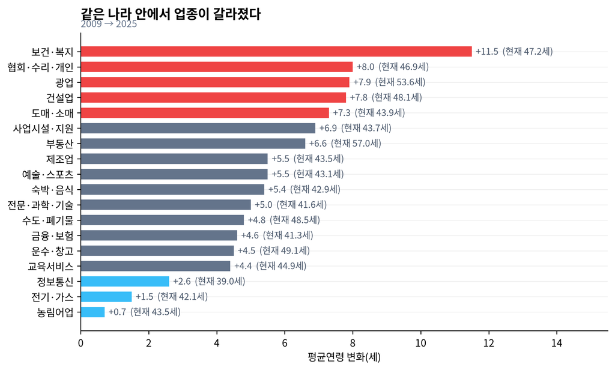

그런데 업종 **이름**으로 나이를 가르면 틀린다. 대분류에서 정보통신업은 **39.0세로 전 업종 중 가장 젊다**. 그러나 그 안을 열면:

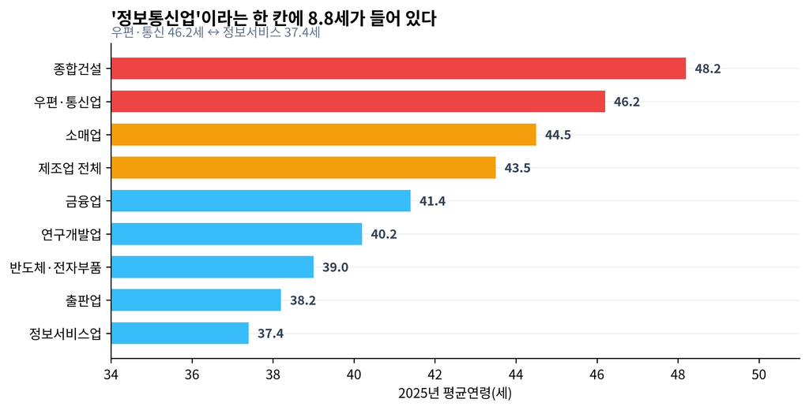

그림 8: 산업중분류 평균연령(2025). 같은 ‘정보통신’ 안에서 우편·통신업과 정보서비스업이 8.8세 벌어져 있다. 출처: 동 조사, 10차 분류.

**우편·통신업 46.2세, 정보서비스업 37.4세.** 같은 대분류 안에서 8.8세가 벌어진다. 반도체가 포함된 전자부품 제조업은 **39.0세**로 제조업 전체(43.5세)보다 4.5세 젊다.

나이를 가르는 것은 업종 이름이 아니다. **그 안에 자본이 지금 들어가고 있는가**다.

# 7 주가는 올랐는데 채용은 반토막났다

여기가 이 분석에서 가장 반직관적인 지점이다.

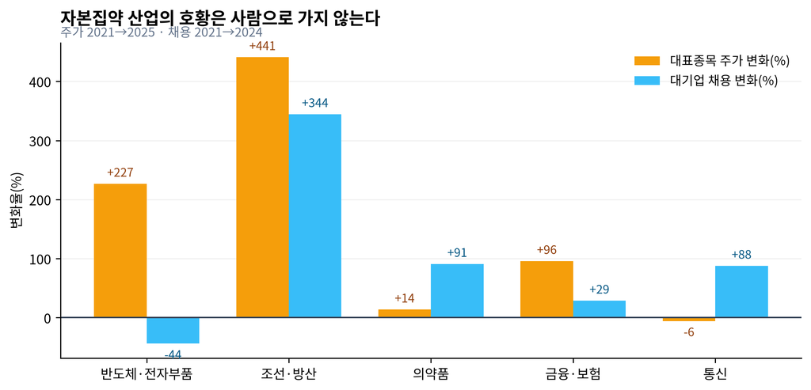

그림 9: 주가 상승률(2021→2025-10-10)과 300인 이상 사업체 연간 채용 변화(2021→2024). 반도체는 정반대로 움직였다. 출처: 네이버 금융 일별시세, 고용노동부 「직종별사업체노동력조사」.

| 산업 | 대표종목 주가 | 대기업 채용 |
| --- | --- | --- |
| 반도체·전자부품 | **+227%** | **−44%** |
| 조선·방산 | **+441%** | **+344%** |
| 의약품 | +14% | +91% |
| 통신 | −6% | +88% |

반도체는 주가가 3배 넘게 뛰는 동안 300인 이상 사업체 연간 채용이 **12,900명 → 7,200명**으로 줄었다. 조선·방산은 주가와 채용이 **같이** 올랐다.

차이는 산업의 **자본집약도**다. 반도체 호황은 **설비**로 간다. 조선 호황은 **사람**으로 간다. 수주 한 건에 용접공이 필요한 산업과, 투자 한 건에 노광장비가 필요한 산업은 같은 “호황”이라는 단어를 공유하지만 고용에 대한 함의가 반대다.

**힌트경계에서만 보이는 세 번째 사실**

금융은 주가를 **미래 현금흐름의 할인**으로 읽고, 노동경제학은 채용을 **생산함수의 노동 투입**으로 읽는다. 두 분야를 따로 두면 “좋은 산업에 가라”는 조언이 나온다. 겹쳐 놓으면 다른 명제가 나온다 — **주가가 오르는 산업에 가라는 조언은 자본집약도를 모르면 반쪽이다.** 공장을 짓는다는 사실만으로는 부족하고, 그 공장이 **사람을 많이 쓰는 종류**여야 한다.

# 8 청년 일자리는 어디로 갔는가

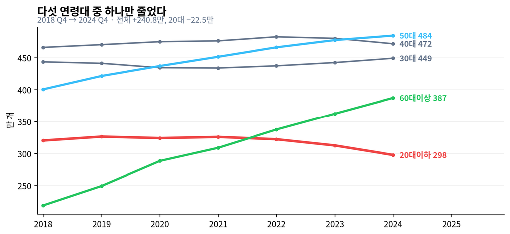

그림 10: 연령대별 임금근로 일자리수(각 연도 4분기). 전체가 240.8만 개 늘어나는 동안 20대 이하만 22.5만 개 줄었다. 출처: 통계청 「임금근로일자리동향행정통계」.

6년간 임금근로 일자리는 **240.8만 개** 늘었다. 그런데 **20대 이하만 −22.5만 개**다. 50대는 +83.8만, 60대 이상은 +168.2만이다.

2022→2024로 좁히면 20대 −24.5만, 50대 +18.3만으로 거의 **일대일 교환**이다. 이 크기는 독립 출처(한국은행 추정 약 21만)와도 일치한다.

# 9 보이지 않는 해고: 1998년은 출구를, 2020년대는 입구를 닫았다

2026년 10월, 한 경제 방송에서 박정호 명지대 교수가 현장을 이렇게 요약했다. **“AI가 들어와도 대량 해고는 거의 일어나지 않는다. 대신 신규 채용을 멈추고, 누가 은퇴해도 바로 충원하지 않는다.”** 그는 이것을 **보이지 않는 해고**라고 불렀다.

이 글의 데이터는 그 서술과 정확히 맞는다. 6년간 임금근로 일자리 총량은 **240.8만 개 늘었다**. 해고가 쏟아졌다면 총량이 줄어야 한다. 줄지 않았다. 대신 20대 이하만 22.5만 개 사라졌다.

그리고 §2의 1999년 그래프가 여기서 의미를 얻는다. **같은 불황 대응인데 방향이 반대다.**

1998년의 조정은 재무제표에 **퇴직급여**로 찍혔고 신문 1면에 났다. 2020년대의 조정은 **채용 공고가 올라오지 않는 방식**으로 일어나므로 어느 장부에도 찍히지 않는다. 비용을 치르는 사람이 아직 그 회사 사람이 아니기 때문이다.

**중요경계 명제 III**

**조정의 비용을 내부자가 치르면 통계에 남고, 외부자가 치르면 통계에 남지 않는다.**

1998년의 감원은 측정되었기 때문에 사회적 논쟁과 정책의 대상이 되었다. 2020년대의 채용 축소는 **같은 크기의 조정이면서도 측정되지 않아** 논쟁의 대상이 되지 못한다. 고령화 통계가 보여주는 것은 노동력의 생물학적 나이가 아니라 **조정 비용이 어느 쪽으로 전가되었는지의 누적 기록**이다.

## 9.1 “대기업이 더 위험하다”는 절반만 맞다

같은 방송에서 나온 또 하나의 주장은 검증 가능하다. **“AI 도입은 중소기업보다 대기업이 빠르므로, 대기업 재직자가 더 빨리 이동을 고민해야 한다.”**

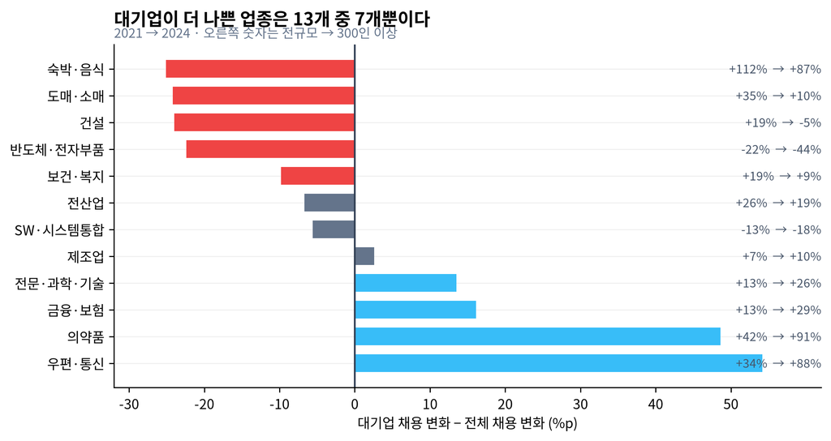

그림 11: 연간 채용 변화 2021→2024, 전규모 대비 300인 이상 사업체. 음(-)이면 대기업이 더 많이 줄였다는 뜻이다. 13개 중 7개에서 대기업이 더 나빴고 중앙값은 -5.7%p다. 조선·방산(+286%p)은 축을 왜곡해 그림에서 제외했고 아래 표에 있다. 출처: 고용노동부 「직종별사업체노동력조사」, 상·하반기 합산.

| 업종 | 전규모 | 300인 이상 | 격차 |
| --- | --- | --- | --- |
| 반도체·전자부품 | −21.7% | **−44.1%** | −22.4%p |
| 건설 | +19.4% | −4.6% | −24.0%p |
| 도매·소매 | +34.6% | +10.4% | −24.2%p |
| **전산업** | +26.2% | +19.4% | **−6.7%p** |
| 금융·보험 | +12.6% | **+28.7%** | +16.1%p |
| 의약품 | +42.2% | **+90.8%** | +48.6%p |
| 조선·방산 | +57.9% | **+344.4%** | +286.5%p |

방향은 맞지만 약하다. 그리고 갈라지는 방식이 더 중요하다. **금융·의약품·조선방산에서는 대기업이 오히려 훨씬 많이 뽑았다.**

## 9.2 이 글이 멈춘 자리 — 측정되지 않는 것은 관리되지 않는다

같은 방송의 마지막 제언은 숫자가 아니라 통계 인프라에 관한 것이었다. **“고용 통계를 직업에서 직무, 과업, 필요 역량까지 쪼개고 연단위를 월단위로 바꿔야 한다. 측정하지 못하면 관리할 수 없고 예산도 배분할 수 없다.”**

이 글을 쓰면서 막힌 지점이 정확히 그 목록이었다.

- **기업별 평균연령**: 공시 항목에 없다. DART 정기공시 직원 현황은 직원수·평균근속연수·1인평균급여까지다.
- **반도체 중분류 연령 분포**: 미공표. §4의 코호트 분석을 제조업 전체로 대리할 수밖에 없었다.
- **신입 채용**: 경력직과 분리된 공식 통계가 없다. §7의 −44%는 “신입이 반토막”이 아니라 “채용 전체가 반토막”이다.
- **채용 자료 주기**: 반년 단위이고 2023년은 한쪽 반기가 결측이다. AI 전환 속도에 비해 해상도가 낮다.
- **이직 사유**: 조사 항목에 ’AI’가 없다. 누가 왜 나갔는지 집계되지 않는다.

# 10 관성계: 착시가 얼마나 오래 가는지는 계산된다

앞 절의 “정지로 체감된다”는 서술은 물리학이 이미 정밀하게 다룬 문제다. **등속으로 움직이는 계 안에서는 자신의 운동을 감지할 수 없다.** 갈릴레오가 1632년 배의 선실로 설명했고, 관측 가능한 것은 절대속도가 아니라 **상대속도**뿐이라는 원리다.

이 원리를 그대로 옮기면 측정 가능한 양이 나온다.

$$v_{\text{상대}} = 1.00 - \frac{d(\text{중위연령})}{dt} \qquad T_{\text{체감정지}} = \frac{5\ \text{세}}{v_{\text{상대}}}$$

사람은 누구나 연 1.00세로 늙는다. 업종 중위는 연 $v$세로 오른다. 관측자에게 남는 것은 그 **차이**뿐이고, ±2.5세(=“내가 딱 중간” 구간)를 빠져나가는 데 걸리는 시간이 착시의 수명이다.

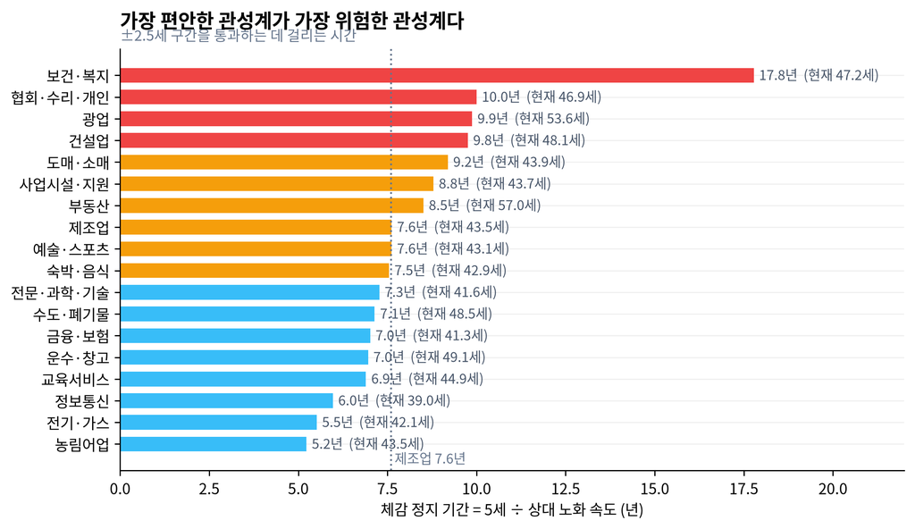

그림 12: 업종별 상대 노화 속도와 ‘나는 늘 중간이었다’ 착시의 지속 기간. 보건·복지에서는 17.8년, 정보통신에서는 6.0년이다. 착시가 길수록 좋은 것이 아니라 아래가 그만큼 비었다는 뜻이다. 출처: 「고용형태별노동실태조사」 2009~2025에서 산출.

| 업종 | 업종 노화 | 상대속도 | 체감 정지 | 현재 |
| --- | --- | --- | --- | --- |
| 보건·복지 | 0.72/년 | 0.28/년 | **17.8년** | 47.2세 |
| 건설업 | 0.49 | 0.51 | 9.8년 | 48.1세 |
| 제조업 | 0.34 | 0.66 | **7.6년** | 43.5세 |
| 금융·보험 | 0.29 | 0.71 | 7.0년 | 41.3세 |
| 정보통신 | 0.16 | 0.84 | **6.0년** | 39.0세 |

제조업의 7.6년은 1976년생 코호트가 실제로 ±2.5세 안에 머문 기간(2014~2022년, 9년)과 맞는다. 같은 사람이 보건·복지에 있었다면 그 감각이 **17.8년** 갔을 것이다.

**중요경계 명제 II**

따라서 이 착시는 개인의 성향이 아니라 **업종의 물성**이다. 그리고 착시가 길다는 것은 좋은 소식이 아니다. 보건·복지에서 17.8년이 나오는 이유는 그 업종의 아래가 가장 빠르게 비었기 때문이다. **가장 오래 안정감을 주는 관성계가 가장 빠르게 늙는 관성계다.**

## 10.1 비유가 깨지는 지점 — 이것도 결과다

물리를 빌려 쓸 때는 **어디까지 옮겨지는지**를 같이 적어야 한다. 세 가지를 시도했고 하나만 살았다.

**① 상대속도 — 성립한다. 단 갈릴레이지 아인슈타인이 아니다.** 위 계산에 광속도, 로런츠 인자도 등장하지 않는다. 쓰인 것은 “관측량은 차이뿐”이라는 **갈릴레이 상대성**이며 특수상대성 이전의 개념이다. 더 중요한 균열이 있다. 상대성에서 등속 운동은 **원리적으로** 검출 불가능하지만, 나이는 거울과 생일로 검출된다. 프레임에 상대적인 것은 노화가 아니라 **사회적 비교**뿐이다. 물리 비유가 아니라 **지각 비유**다.

**② 시간 지연 — 성립하지 않는다.** 특수상대성의 시간 지연은 **상호적**이다. 두 관측자가 서로의 시계가 느리다고 본다. “계 내부만 느리게 흐른다”는 일방향 진술은 가속·비대칭(쌍둥이 역설)이나 중력장에서만 성립한다. 게다가 $\gamma$는 $v^2/c^2$에 걸려 있어 저속에서 사실상 1이다. 대응하는 양이 없다.

다만 **고유시간(proper time)** 개념은 살릴 수 있다. 주관적 시간은 시계가 아니라 **사건 밀도**로 흐른다. 후배가 들어오고, 기수가 쌓이고, 승진이 생기는 사건들이다. 그 사건율이 측정 가능하다 — 제조업 30세 미만 비중이 23.5%에서 13.9%로 반토막 났으므로 아래에서 올라오는 사건도 그만큼 줄었다. 비유를 **가설**로 바꾸면 이렇게 된다. 이 글은 그 가설을 제기만 하고 **검증하지 않았다**.

**③ 중력장 — 기각한다. 순환이기 때문이다.** “고령화라는 중력이 좌표계를 휜다”는 서술에는 계량도 곡률도 측지선도 없다. 더 치명적인 것은 **같은 양을 두 번 부른다**는 점이다. 여기서 ’중력원’은 연령 분포이고 ’휘어진 좌표’는 **그 분포의 중앙값**이다. 분포가 분포의 중앙값을 끌어당긴다는 말은 항진명제다. 모형이 아니라 재진술이며, 설명력이 0이다.

**힌트경계에서만 보이는 네 번째 사실**

물리 비유의 가치는 그럴듯함이 아니라 **반증 가능한 양을 만들어내는가**에 있다. ①은 $v_{\text{상대}}$와 $T_{\text{체감정지}}$라는 숫자를 만들었으므로 분석이고, ③은 어떤 숫자도 만들지 못했으므로 수사다. **같은 이론에서 나온 세 비유의 운명이 갈린 기준은 물리학적 정확성이 아니라 측정 가능성이었다.**

# 11 종합: 기업의 나이는 자본배분의 흔적이다

- **노동경제학**: 연공 임금은 후불 계약이다. 성장이 멈추면 갚을 수 없다.
- **인구통계학**: 코호트가 줄었다. 아래가 얇다.
- **자본이론**: 투자는 산업별로 불균등하고, 자본집약 산업에서는 투자가 고용으로 번역되지 않는다.
- **관성계의 물리**: 관측 가능한 것은 절대속도가 아니라 상대속도뿐이다. 그래서 느린 교차는 정지로 보인다.

네 조각을 겹치면 각각에는 없던 명제가 나온다. 그리고 §9에서 본 것처럼, 조정의 비용이 내부자에게 가면 통계에 남고 외부자에게 가면 남지 않는다.

**노트경계 명제**

**조직의 중위 연령은 그 조직이 최근 몇 년간 어디에 돈을 넣었는지를 보여주는 지표다.**

평균 근속이 멈춘 채 평균 연령만 오르면 그것은 체류가 아니라 결손이다. 결손은 채용에서 생기고, 채용은 투자를 따라간다. 따라서 중위 연령은 인구 지표가 아니라 **지연된 자본배분 지표**다. 한 사람이 중위에 오래 머물렀다는 것은 그 사람의 전형성이 아니라, **그의 아래로 돈이 들어오지 않은 기간의 길이**를 측정한 값이다.

이 명제는 실무적으로 검증 가능한 예측을 만든다. **어떤 회사의 30세 미만 비중은 그 회사의 2~3년 전 설비투자 증가율을 따라간다.** 반도체가 2021년 대비 채용을 반 토막 낸 것은 2023년 메모리 불황의 지연 반영이고, AI 메모리 투자의 고용 효과는 2025~2026년 자료에서 나타나야 한다. 이 글은 그 검증 **직전**에 쓰였다.

**경고반대 해석 — 이 분석이 틀릴 수 있는 지점**

**1. 중위 연령은 자본이 아니라 단순 인구 때문일 수 있다.** 1976년생은 약 80만 명, 2000년대생은 60만 명대다. 아래가 얇은 것이 투자 부족이 아니라 **출생아 수** 때문이라면 이 글의 인과는 뒤집힌다. 반론: 그렇다면 업종 간 격차(광업 53.6세 ↔︎ 정보서비스 37.4세, 16.2세)가 설명되지 않는다. 모든 업종이 같은 인구 풀에서 뽑기 때문이다. 다만 **업종별 선호도 차이**가 인구 효과를 매개할 수 있고, 이 글은 그것을 분리하지 못했다.

**2. 근속이 안 늘어난 것은 이직 증가 때문일 수 있다.** 평균 근속 정체를 “유입 결손”으로 읽었지만, 경력직 이동이 활발해져 **같은 사람이 여러 회사를 거치는** 경우에도 근속은 정체한다. 이 경우 조직은 비어서 늙은 것이 아니라 **회전하면서** 늙은 것이다. 두 해석을 가르려면 개인 단위 패널 자료가 필요하고, 이 글에는 없다.

**3. 제조업으로 반도체를 대리한 것은 약점이다.** 중분류 연령 분포가 공표되지 않아 1976년생 코호트 분석을 **제조업 전체**로 수행했다. 전자부품 제조업 평균은 39.0세로 제조업(43.5세)보다 4.5세 젊으므로, 반도체·디스플레이에서는 교차 시점이 **더 늦고** 현재 격차가 **더 클** 가능성이 높다. 방향은 같지만 크기는 다를 수 있다.

**4. “채용”은 신입이 아니다.** 고용노동부 채용인원에는 경력직이 포함된다. 반도체 −44%는 “신입이 반토막”이 아니라 “채용 전체가 반토막”이다. 신입만 분리한 공식 통계는 존재하지 않는다.

**5. 주가-채용 비교는 시점이 어긋나 있다.** 주가는 2025년 10월까지, 채용은 2024년까지다. 2025년 채용 자료가 나오면 반도체 −44%는 완화될 가능성이 크다. 이 글의 가장 약한 숫자다.

**7. 체감 정지 기간은 선형 외삽이다.** $T = 5/v_{\text{상대}}$는 중위연령이 **일정 속도로** 오른다고 가정한다. 실제로는 제조업 중위가 2021년 이후 43.4세 부근에서 정체했다. 정체가 계속되면 상대속도가 1.00에 가까워져 체감 정지는 **5년으로 수렴**한다. 즉 이 지표는 과거 16년의 평균 기울기이지 미래 예측이 아니다.

**8. “보이지 않는 해고”는 측정되지 않았으므로 증명되지도 않았다.** §9의 논증은 “총량이 늘었는데 20대만 줄었다”는 **간접 증거**다. 기업이 실제로 “채용을 멈추기로” 결정했는지, 아니면 지원자 풀·산업구조 변화의 결과인지 이 자료로는 구분할 수 없다. 의도를 보려면 기업 단위 채용계획 자료가 필요하고 공개 통계에는 없다. 이 글이 “측정되지 않는다”고 말한 바로 그 공백이 이 주장 자체에도 적용된다.

**9. 대기업 비교는 300인 기준의 산물이다.** 300인 이상을 ’대기업’으로 본 것은 조사 구분을 따른 것이지 경제적 정의가 아니다. 기준을 1,000인으로 올리면 결과가 달라질 수 있고, 그 구분은 공표되지 않는다. 또 2021년을 기준연도로 잡은 것은 자료 제약(10차 분류 시작)이지 경기 중립적 선택이 아니다. 2021년은 반도체 호황기여서 **분모가 높다**.

**10. 모집단이 서로 다르다.** 평균연령은 상용 5인 이상, 일자리동향은 전체 임금근로, 채용은 사업체 1인 이상이다. 서로 더하거나 비율로 나누면 안 된다. 이 글은 각 지표를 **독립적으로만** 사용했다.

# 12 참고 문헌

- 통계청·고용노동부, 「고용형태별노동실태조사」(구 임금구조기본통계조사), 1993~2025. KOSIS 표 `DT_PAYN003`·`DT_PAYN103`·`DT_118N_PAYN32`·`DT_118N_PAYN42`·`DT_118N_PAYN43`·`DT_118N_PAYN20`·`DT_118N_PAYN30`.
- 통계청, 「경제활동인구조사 고령층 부가조사」, 2013~2024. KOSIS 표 `DT_1DE8036S`(가장 오래 근무한 일자리를 그만둔 연령 및 평균이직연령).
- 통계청, 「임금근로일자리동향행정통계」, 2018~2024. KOSIS 표 `DT_1FL_7008`(연령 및 산업대분류별 임금근로 일자리).
- 고용노동부, 「직종별사업체노동력조사」, 2021~2024. KOSIS 표 `DT_118N_DEN051`·`DT_118N_DEN061`(산업별·규모별 채용인원).
- 네이버 금융 일별시세, 2021-01-04 ~ 2025-10-10.
- 박정호(명지대), 「채용 소멸 시대, 회사 밖에는 답이 없습니다」, MBC 손에잡히는경제, 2026-10-10. 본문에서 검증 대상으로 인용했다.
- ILO 생성형 AI 노출 지수(2025 개정) 수치는 위 방송의 인용을 재인용한 것이며 **원문을 직접 확인하지 않았다**.
- 원자료·수집 스크립트: `output/data/sp40/`.

*모든 수치는 KOSIS OpenAPI로 직접 수집해 재현 가능하다. 특정 기업의 내부 자료는 일절 사용하지 않았다.*